# BRFSS 2021 – Asthma Analysis (Instructional Notebook)

ECON145 Instructors

07 September, 2025

# 1 Overview

This instructional notebook walks you through an end-to-end analysis of asthma using the **2021 Behavioral Risk Factor Surveillance System (BRFSS)** dataset.

**Learning outcomes**

- Load, inspect, and clean survey data in R.
- Convert coded variables into human-readable labels using *factors*.
- Produce a **Table 1**-style summary for categorical variables.
- Visualize distributions (histogram, ECDF, and boxplot).
- Explore BMI distributions by smoking status.
- Join state **FIPS** mappings and build a **US choropleth** of asthma prevalence by state.

# 2 Setup

```r
# Core packages
library(dplyr)
library(ggplot2)
library(readr)
library(plotly)

# Set a reproducible theme
theme_set(theme_minimal(base_size = 14))

# User path to data (edit this to your local path)
# Keep check.names = FALSE so names like `_STATE` remain untouched.
file_path <- "D:/1_Teaching_Work_Folder/_SMU_Courses/ECON145_Intro to Healthcare Analytics/2025/Aug_2025/Hands-On/Lecture 3/2. BRFSS"
```

# 3 Load Data

```r
# Replace with your actual filename
# The dataset is assumed to be a CSV already filtered to relevant BRFSS 2021 fields.
df_asthma <- read_csv(
  file.path(file_path, "brfss2021_asthma.csv"),
  show_col_types = FALSE
)

# If your CSV was read with base R and lost underscores, you can prevent name changes with:
# df_asthma <- read.csv(file.path(file_path, "brfss2021_asthma.csv"),
#                       check.names = FALSE, stringsAsFactors = FALSE)

# Quick structure and preview
glimpse(df_asthma)
```

```
## Rows: 438,693
## Columns: 15
## $ `_AGEG5YR` <dbl> 11, 10, 11, 9, 12, 13, 9, 9, 12, 10, 10, 12, 11, 11, 12, 9,…
## $ `_AGE80`   <dbl> 70, 67, 72, 62, 76, 80, 63, 62, 78, 65, 67, 76, 73, 73, 77,…
## $ SEXVAR     <dbl> 2, 2, 2, 2, 1, 1, 1, 1, 2, 2, 2, 2, 2, 2, 2, 2, 2, 1, 2, 2,…
## $ `_IMPRACE` <dbl> 1, 2, 2, 1, 6, 1, 1, 1, 1, 1, 1, 1, 1, 1, 1, 1, 1, 1, 1, 1,…
## $ EDUCA      <dbl> 4, 6, 4, 4, 3, 5, 6, 3, 3, 4, 5, 4, 3, 6, 4, 6, 4, 6, 4, 4,…
## $ `_INCOMG1` <dbl> 3, 9, 2, 5, 2, 4, 9, 9, 9, 5, 2, 2, 9, 9, 9, 5, 3, 5, 9, 4,…
## $ EMPLOY1    <dbl> 7, 8, 7, 7, 8, 7, 8, 2, 7, 7, 7, 7, 5, 7, 7, 7, 5, 7, 7, 1,…
## $ MARITAL    <dbl> 1, 9, 3, 1, 1, 1, 1, 2, 2, 1, 2, 3, 1, 1, 3, 1, 1, 1, 2, 5,…
## $ `_STATE`   <dbl> 1, 1, 1, 1, 1, 1, 1, 1, 1, 1, 1, 1, 1, 1, 1, 1, 1, 1, 1, 1,…
## $ `_SMOKER3` <dbl> 3, 4, 4, 4, 4, 3, 4, 3, 4, 3, 2, 4, 4, 4, 4, 3, 3, 4, 4, 4,…
## $ `_BMI5`    <dbl> 1454, NA, 2829, 3347, 2873, 2437, 4611, 2274, NA, 3994, 274…
## $ IDATE      <dbl> 1192021, 1212021, 1212021, 1172021, 1152021, 1142021, 10820…
## $ SEQNO      <dbl> 2.021e+09, 2.021e+09, 2.021e+09, 2.021e+09, 2.021e+09, 2.02…
## $ ASTHMA3    <dbl> 1, 2, 2, 2, 2, 2, 2, 2, 2, 2, 1, 2, 2, 2, 2, 2, 2, 2, 2, 1,…
## $ ASTHNOW    <dbl> 1, NA, NA, NA, NA, NA, NA, NA, NA, NA, 1, NA, NA, NA, NA, N…
```

**Teaching notes**

- `glimpse()` (from `dplyr`) is like `info()` in pandas: it shows column names and types, plus a preview of values.
- For survey data, many variables are categorical (best stored as **factors**).

# 4 Clean & Label Variables

We convert coded numerics to labeled factors. This improves plots, summaries, and modeling.

```r
# 2.1 Age (5-year groups) — ordered factor
df_asthma <- df_asthma %>%
  mutate(
    `_AGEG5YR` = factor(`_AGEG5YR`,
                        levels = 1:14,
                        labels = c("18–24","25–29","30–34","35–39","40–44","45–49",
                                   "50–54","55–59","60–64","65–69","70–74","75–79","80+","Unknown"),
                        ordered = TRUE),
    # 2.2 Sex
    SEXVAR = factor(SEXVAR,
                    levels = c(1,2,9),
                    labels = c("Male","Female","Refused")),
    # 2.3 Race/Ethnicity
    `_IMPRACE` = factor(`_IMPRACE`,
                        levels = c(1,2,3,4,5,6,7,9),
                        labels = c("White NH","Black NH","Asian NH","Pacific NH",
                                   "FirstNation NH","Multiracial NH","Hispanic","Unknown")),
    # 2.4 Education — ordered
    EDUCA = factor(EDUCA,
                   levels = c(1,2,3,4,5,6,9),
                   labels = c("No formal education","Grades 1–8","Grades 9–11",
                              "High school graduate","Some college","College graduate","Refused"),
                   ordered = TRUE),
    # 2.5 Income — ordered
    `_INCOMG1` = factor(`_INCOMG1`,
                        levels = c(1,2,3,4,5,6,9),
                        labels = c("<$15,000","$15–25k","$25–35k","$35–50k","$50–75k","$75k+","Unknown"),
                        ordered = TRUE),
    # 2.6 Employment
    EMPLOY1 = factor(EMPLOY1,
                     levels = 1:9,
                     labels = c("Employed for wages","Self-employed","Out of work ≥1yr",
                                "Out of work <1yr","Homemaker","Student","Retired",
                                "Unable to work","Refused")),
    # 2.7 Marital
    MARITAL = factor(MARITAL,
                     levels = c(1,2,3,4,5,6,9),
                     labels = c("Married","Divorced","Widowed","Separated",
                                "Never married","Unmarried couple","Refused")),
    # 2.8 Smoker status
    `_SMOKER3` = factor(`_SMOKER3`,
                        levels = c(1,2,3,4,9),
                        labels = c("Current smoker (every day)","Current smoker (some days)",
                                   "Former smoker","Never smoked","Don't know / Refused / Missing")),
    # 2.9 Asthma ever
    ASTHMA3 = factor(ASTHMA3,
                     levels = c(1,2,7,9),
                     labels = c("Yes","No","Don't know / Not sure","Refused"))
  )

# 2.10 Convert BMI to numeric and scale by 100
df_asthma <- df_asthma %>%
  mutate(`_BMI5` = as.numeric(`_BMI5`) / 100)
```

**Teaching notes**

- Use **factors** for categories. Use `ordered = TRUE` for ordinal categories (e.g., education and income).
- `_BMI5` in BRFSS is stored as BMI×100; divide by 100 to recover BMI.

# 5 Categorical Summary (Table 1 style)

We’ll build a helper to count categories and proportions (including missing).

```r
summarize_categorical <- function(df, vars_to_summarize) {
  out <- lapply(vars_to_summarize, function(var) {
    x <- df[[var]]
    freq <- table(x, useNA = "always")
    prop <- prop.table(freq) * 100

    cats <- names(freq)
    # NA in names(freq) appears as NA (not "<NA>")
    cats[is.na(cats)] <- "Missing"

    data.frame(
      Variable = var,
      Category = cats,
      Count = as.integer(freq),
      `Proportion (%)` = round(as.numeric(prop), 1),
      check.names = FALSE,
      stringsAsFactors = FALSE
    )
  })
  do.call(rbind, out)
}

cat_vars <- c("_AGEG5YR","SEXVAR","_IMPRACE","EDUCA","_INCOMG1",
              "EMPLOY1","MARITAL","_STATE","_SMOKER3","ASTHMA3","ASTHNOW")

demo_summary <- summarize_categorical(df_asthma, cat_vars)

head(demo_summary, 15)
```

|  | Variable | Category | Count | Proportion (%) |
| --- | --- | --- | --- | --- |
| 1 | _AGEG5YR | 18–24 | 26025 | 5.9 |
| 2 | _AGEG5YR | 25–29 | 21623 | 4.9 |
| 3 | _AGEG5YR | 30–34 | 25724 | 5.9 |
| 4 | _AGEG5YR | 35–39 | 28559 | 6.5 |
| 5 | _AGEG5YR | 40–44 | 29435 | 6.7 |
| 6 | _AGEG5YR | 45–49 | 28391 | 6.5 |
| 7 | _AGEG5YR | 50–54 | 34086 | 7.8 |
| 8 | _AGEG5YR | 55–59 | 38009 | 8.7 |
| 9 | _AGEG5YR | 60–64 | 44298 | 10.1 |
| 10 | _AGEG5YR | 65–69 | 45762 | 10.4 |

[output cut: 5 more lines]

**Teaching notes**

- `table(..., useNA = "always")` keeps missing values.
- If variables are **factors**, output respects the factor level order, which is helpful in reporting.

# 6 Visualizing Age Distributions by Asthma Status

We compare age distributions for respondents with and without asthma using a histogram, ECDF, and boxplot.

## 6.1 Histogram (overlaid)

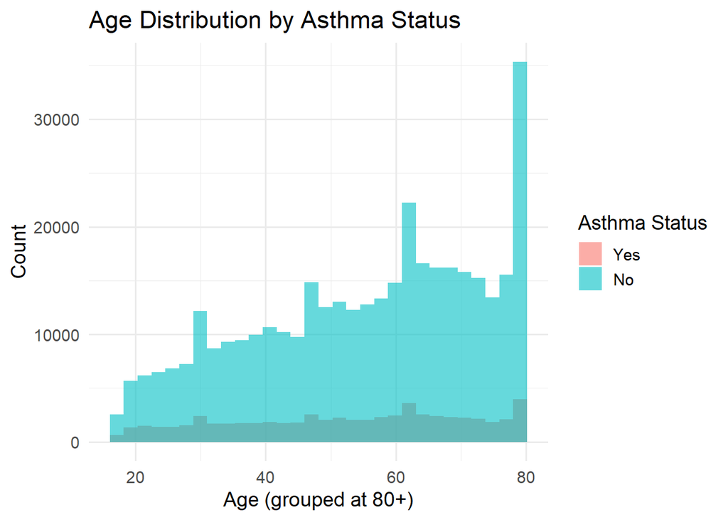

```r
df_asthma_age <- df_asthma %>%
  select(`_AGE80`, ASTHMA3) %>%
  filter(ASTHMA3 %in% c("Yes","No")) %>%
  droplevels()

ggplot(df_asthma_age, aes(x = `_AGE80`, fill = ASTHMA3)) +
  geom_histogram(bins = 30, position = "identity", alpha = 0.6) +
  labs(
    title = "Age Distribution by Asthma Status",
    x = "Age (grouped at 80+)",
    y = "Count",
    fill = "Asthma Status"
  )
```

## 6.2 ECDF (empirical CDF)

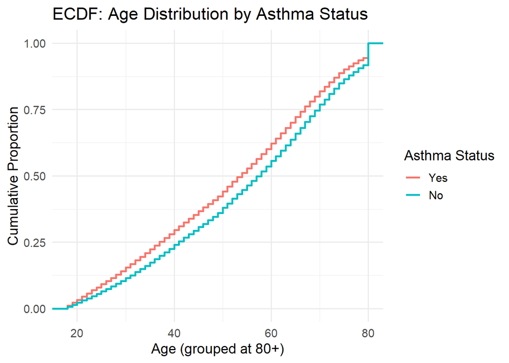

```r
ggplot(df_asthma_age, aes(x = `_AGE80`, color = ASTHMA3)) +
  stat_ecdf(linewidth = 1) +
  labs(
    title = "ECDF: Age Distribution by Asthma Status",
    x = "Age (grouped at 80+)",
    y = "Cumulative Proportion",
    color = "Asthma Status"
  )
```

## 6.3 Boxplot

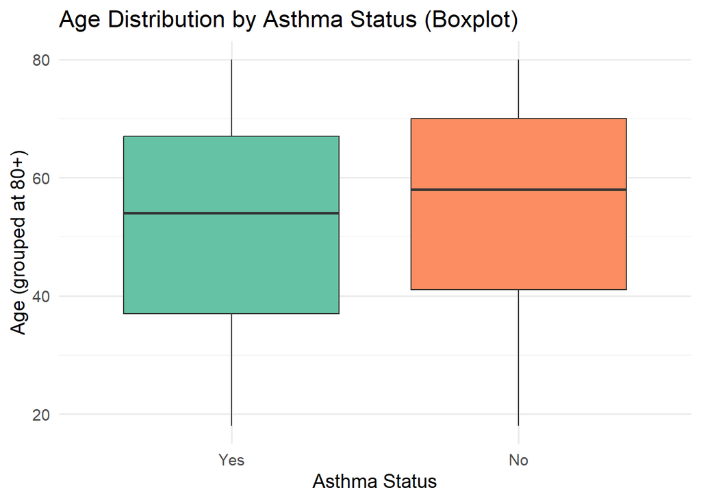

```r
ggplot(df_asthma_age, aes(x = ASTHMA3, y = `_AGE80`, fill = ASTHMA3)) +
  geom_boxplot() +
  scale_fill_brewer(palette = "Set2") +
  labs(
    title = "Age Distribution by Asthma Status (Boxplot)",
    x = "Asthma Status",
    y = "Age (grouped at 80+)"
  ) +
  theme(legend.position = "none")
```

**Teaching notes**

- **Histogram** shows the shape of distributions; overlap/transparency helps compare groups.
- **ECDF** compares distributions across the entire range.
- **Boxplot** summarizes median and IQR, highlighting shifts and outliers.

# 7 BMI by Smoking Status

We explore BMI differences across smoking categories. We also cap extreme BMI values to focus on realistic ranges (< 50).

```r
valid_smoker <- c("Current smoker (every day)",
                  "Current smoker (some days)",
                  "Former smoker",
                  "Never smoked")

df_smoker <- df_asthma %>%
  filter(`_SMOKER3` %in% valid_smoker) %>%
  mutate(`_BMI5` = as.numeric(`_BMI5`)) %>%
  filter(!is.na(`_BMI5`) & `_BMI5` < 50) %>%
  droplevels()          # remove NA or BMI > 50

sum(is.na(df_smoker$`_BMI5`))
```

```
## [1] 0
```

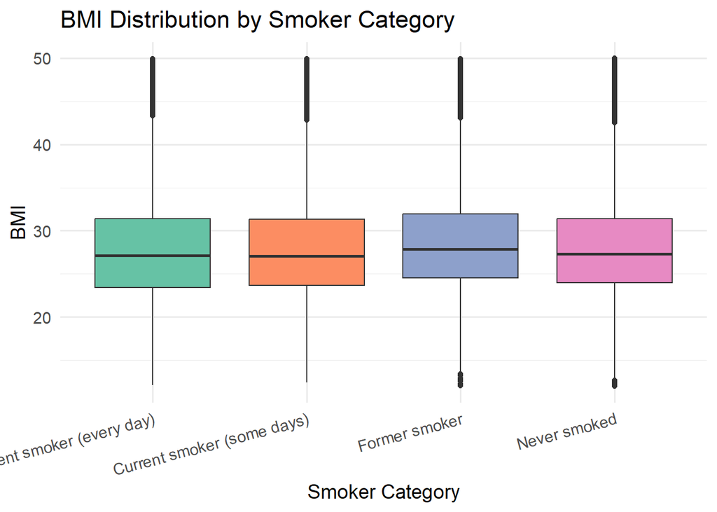

```r
ggplot(df_smoker, aes(x = `_SMOKER3`, y = `_BMI5`, fill = `_SMOKER3`)) +
  geom_boxplot() +
  scale_fill_brewer(palette = "Set2") +
  labs(
    title = "BMI Distribution by Smoker Category",
    x = "Smoker Category",
    y = "BMI"
  ) +
  theme(legend.position = "none",
        axis.text.x = element_text(angle = 15, hjust = 1))
```

**Teaching notes**

- BRFSS BMI above 50 is extremely rare; trimming helps focus interpretation.
- Factor labels make axis tick labels self-explanatory.

# 8 State Mapping (FIPS) & Choropleth

We join state **FIPS** codes to derive state abbreviations and names; then, we compute asthma prevalence by state and visualize a **US choropleth**.

```r
# 6.1 Load state FIPS mapping (| delimited), expected columns: STATE, STUSAB, STATE_NAME
fips_mapping <- read_delim(file.path(file_path, "state_fips.csv"),
                           delim = "|", show_col_types = FALSE) %>%
  mutate(STATE = as.integer(STATE))

# 6.2 Ensure `_STATE` is integer for joining
df_asthma <- df_asthma %>% mutate(`_STATE` = as.integer(`_STATE`))

# 6.3 Join on STATE FIPS
df_asthma <- df_asthma %>%
  left_join(fips_mapping, by = c("_STATE" = "STATE"))

# 6.4 Create a cleaned Yes/No variable for aggregation
df_state <- df_asthma %>%
  mutate(ASTHMA3_clean = case_when(
    ASTHMA3 %in% c("Yes") ~ "Yes",
    ASTHMA3 %in% c("No")  ~ "No",
    TRUE ~ NA_character_
  ))

# 6.5 Aggregate by state
state_summary <- df_state %>%
  group_by(STUSAB) %>%
  summarise(
    Total = n(),
    Yes = sum(ASTHMA3_clean == "Yes", na.rm = TRUE),
    .groups = "drop"
  ) %>%
  mutate(Proportion = Yes / Total) %>%
  left_join(df_state %>% distinct(STUSAB, STATE_NAME), by = "STUSAB")

# 6.6 Plotly choropleth (USA)
fig <- plot_ly(
  data = state_summary,
  type = "choropleth",
  locations = ~STUSAB,
  locationmode = "USA-states",
  z = ~Proportion,
  colorscale = "Blues",
  colorbar = list(title = "Asthma Prevalence")
) %>%
  layout(
    title = "Proportion of Asthma (Yes) Cases by State",
    geo = list(scope = "usa", bgcolor = "rgba(0,0,0,0)")
  ) %>%
  style(
    hoverinfo = "text",
    text = ~paste0(
      STATE_NAME, "<br>",
      "Yes: ", Yes, "<br>",
      "Total: ", Total, "<br>",
      "Proportion: ", percent(Proportion, accuracy = 0.01)
    )
  )

fig
```

[interactive chart not shown]

**Teaching notes**

- `left_join()` attaches state abbreviations and names to each record.
- Aggregation at state level supports geographic storytelling.
- Choropleth maps are effective for **regional patterns**, but always accompany them with **numerical summaries**.

# 9 Practice Exercises

1. Create a **Table 1** of demographic variables for asthma vs. non-asthma (Yes/No) side-by-side.
2. Replace the histogram with **density plots** (`geom_density()`) and discuss the pros/cons.
3. Add **mean BMI points** on top of the smoker boxplots (`stat_summary(fun = "mean")`).
4. Re-compute state prevalence **excluding** respondents with missing asthma status; compare to the original.
5. Export your summary table using `write_csv()`.

# 10 Key Takeaways

- In health surveys, **factor labeling** is essential for clarity.
- Use **ordered factors** for ordinal categories (education, income, age bands).
- Always perform **EDA** with both **tables and plots** for a rounded view.
- For maps, verify **join keys** (like FIPS) and **coverage** before interpreting patterns.